# MEE 621 - Activity 4 Tibbles

### This is the answers of the exercise by Junmar Sales II

### Email: 92922@usc.edu.ph

### Dated 14 October 2020.

### You can also see this on my github pages: [MEE 621 - Activity 4 on Tibbles](https://92922.github.io/dist/MEE621_Tibbles.html)

This report on the answers of the exercises outline Activity 4 on Tibbles all done in R Studio.

Let’s load the prerequisite libraries, we have assumes that packages has been installed.

```r
library("tidyverse")
```

# 10.5 Exercises

## How can you tell if an object is a tibble? (Hint: try printing mtcars , which is a regular data frame).

Let’s try to check what the hint suggests by printing `mtcars`. We noticed it prints all the columns.

```r
mtcars
```

|  | mpg | cyl | disp | hp | drat | wt | qsec | vs | am | gear | carb |
| --- | --- | --- | --- | --- | --- | --- | --- | --- | --- | --- | --- |
| Mazda RX4 | 21.0 | 6 | 160.0 | 110 | 3.90 | 2.620 | 16.46 | 0 | 1 | 4 | 4 |
| Mazda RX4 Wag | 21.0 | 6 | 160.0 | 110 | 3.90 | 2.875 | 17.02 | 0 | 1 | 4 | 4 |
| Datsun 710 | 22.8 | 4 | 108.0 | 93 | 3.85 | 2.320 | 18.61 | 1 | 1 | 4 | 1 |
| Hornet 4 Drive | 21.4 | 6 | 258.0 | 110 | 3.08 | 3.215 | 19.44 | 1 | 0 | 3 | 1 |
| Hornet Sportabout | 18.7 | 8 | 360.0 | 175 | 3.15 | 3.440 | 17.02 | 0 | 0 | 3 | 2 |
| Valiant | 18.1 | 6 | 225.0 | 105 | 2.76 | 3.460 | 20.22 | 1 | 0 | 3 | 1 |
| Duster 360 | 14.3 | 8 | 360.0 | 245 | 3.21 | 3.570 | 15.84 | 0 | 0 | 3 | 4 |
| Merc 240D | 24.4 | 4 | 146.7 | 62 | 3.69 | 3.190 | 20.00 | 1 | 0 | 4 | 2 |
| Merc 230 | 22.8 | 4 | 140.8 | 95 | 3.92 | 3.150 | 22.90 | 1 | 0 | 4 | 2 |
| Merc 280 | 19.2 | 6 | 167.6 | 123 | 3.92 | 3.440 | 18.30 | 1 | 0 | 4 | 4 |

[output cut: 22 more lines]

Let’s use is_tibble() to check whether a data frame is a tibble or not. .

```r
is_tibble(mtcars)
```

```
## [1] FALSE
```

The mtcars data frame is not a tibble

when we first convert mtcars to a tibble using as_tibble(), it prints only the first ten observations.

```r
as_tibble(mtcars)
```

| mpg | cyl | disp | hp | drat | wt | qsec | vs | am | gear | carb |
| --- | --- | --- | --- | --- | --- | --- | --- | --- | --- | --- |
| 21.0 | 6 | 160.0 | 110 | 3.90 | 2.620 | 16.46 | 0 | 1 | 4 | 4 |
| 21.0 | 6 | 160.0 | 110 | 3.90 | 2.875 | 17.02 | 0 | 1 | 4 | 4 |
| 22.8 | 4 | 108.0 | 93 | 3.85 | 2.320 | 18.61 | 1 | 1 | 4 | 1 |
| 21.4 | 6 | 258.0 | 110 | 3.08 | 3.215 | 19.44 | 1 | 0 | 3 | 1 |
| 18.7 | 8 | 360.0 | 175 | 3.15 | 3.440 | 17.02 | 0 | 0 | 3 | 2 |
| 18.1 | 6 | 225.0 | 105 | 2.76 | 3.460 | 20.22 | 1 | 0 | 3 | 1 |
| 14.3 | 8 | 360.0 | 245 | 3.21 | 3.570 | 15.84 | 0 | 0 | 3 | 4 |
| 24.4 | 4 | 146.7 | 62 | 3.69 | 3.190 | 20.00 | 1 | 0 | 4 | 2 |
| 22.8 | 4 | 140.8 | 95 | 3.92 | 3.150 | 22.90 | 1 | 0 | 4 | 2 |
| 19.2 | 6 | 167.6 | 123 | 3.92 | 3.440 | 18.30 | 1 | 0 | 4 | 4 |

[output cut: 22 more lines]

Furthermore, we could look at printing, e.g. only prints first 10 rows and enough variables where you can see them all, or by checking explicitly the class function.

## Compare and contrast the following operations on a data.frame and equivalent tibble. What is different? Why might the default data frame behaviours cause you frustration?

```r
df <- data.frame(abc = 1, xyz = "a")
df$x
```

```
## [1] "a"
```

```r
df[, "xyz"]
```

```
## [1] "a"
```

```r
df[, c("abc", "xyz")]
```

| abc | xyz |
| --- | --- |
| 1 | a |

```r
tbl <- as_tibble(df)
tbl$x
```

[output not shown]

```r
tbl[, "xyz"]
```

| xyz |
| --- |
| a |

```r
tbl[, c("abc", "xyz")]
```

| abc | xyz |
| --- | --- |
| 1 | a |

The `$` operator will match any column name that starts with the name following it. Since there is a column named `xyz`, the expression `df$x` will be expanded to `df$xyz`. This behavior of the `$` operator saves a few keystrokes, but it can result in accidentally using a different column than you thought you were using.

With data.frames, with [ the type of object that is returned differs on the number of columns. If it is one column, it won’t return a data.frame, but instead will return a vector. With more than one column, then it will return a data.frame. This is fine if you know what you are passing in, but suppose you did df[ , vars] where vars was a variable. Then what that code does depends on length(vars) and you’d have to write code to account for those situations or risk bugs.

Therefore: Tibbles never change type of input e.g. from strings to factors Tibbles never change names of variables, never creates row names Tibbles print in a more concise and readable format This difference is made more stark if working with list-columns

## If you have the name of a variable stored in an object, e.g. `var <- "mpg"` , how can you extract the reference variable from a tibble?

You can use the double bracket, like df[[var]]. You cannot use the dollar sign, because `df$var` would look for a column named var.

```r
var <- "mpg"
# Will extract the column as an atomic vector
df[[var]]
```

[output not shown]

## Practice referring to non-syntactic names in the following data frame by:

```r
df <- tibble(`1` = 1:10, `2` = 11:20)
```

### Extracting the variable called 1 .

```r
df %>%
  select(1)
```

| 1 |
| --- |
| 1 |
| 2 |
| 3 |
| 4 |
| 5 |
| 6 |
| 7 |
| 8 |
| 9 |
| 10 |

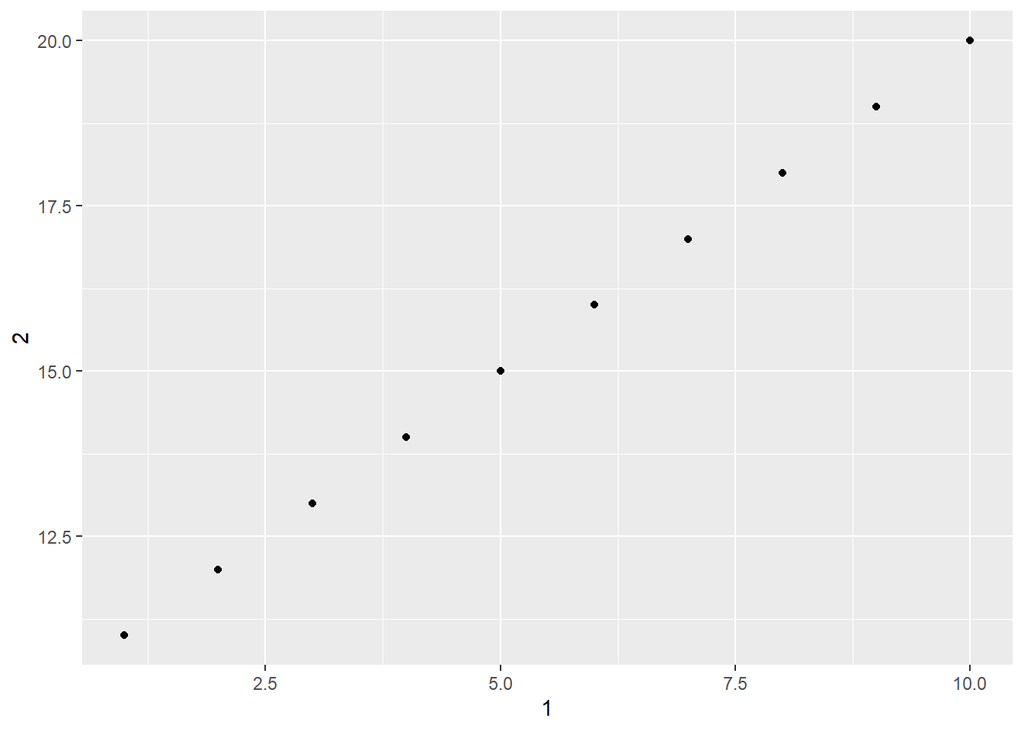